# Lab_8

### Defining Models and Workflows

```r
# Define model
lm_model <- linear_reg() %>%
  # define the engine
  set_engine("lm") %>%
  # define the mode
  set_mode("regression")

# Instantiate a workflow ...
lm_wf <- workflow() %>%
  # Add the recipe
  add_recipe(rec) %>%
  # Add the model
  add_model(lm_model) %>%
  # Fit the model to the training data
  fit(data = camels_train)

rf_model <- rand_forest() %>%
  set_engine("ranger", importance = "impurity") %>%
  set_mode("regression")

rf_wf <- workflow() %>%
  # Add the recipe
  add_recipe(rec) %>%
  # Add the model
  add_model(rf_model) %>%
  # Fit the model
  fit(data = camels_train)

b_model<- boost_tree()%>%
  set_engine('xgboost')%>%
  set_mode('regression')

bm_wf<- workflow()%>%
  add_recipe(rec)%>%
  add_model(b_model)%>%
  fit(data=camels_train)
```

### Predictions

```r
lm_data <- augment(lm_wf, new_data = camels_test)
dim(lm_data)
```

```
[1] 135  61
```

```r
rf_data <- augment(rf_wf, new_data = camels_test)
dim(rf_data)
```

```
[1] 135  60
```

```r
bm_data<- augment(bm_wf, new_data=camels_test)
dim(bm_data)
```

```
[1] 135  60
```

### Model Evaluations

```r
metrics(lm_data, truth = logQmean, estimate = .pred)
```

```
# A tibble: 3 × 3
  .metric .estimator .estimate
  <chr>   <chr>          <dbl>
1 rmse    standard       0.583
2 rsq     standard       0.742
3 mae     standard       0.390
```

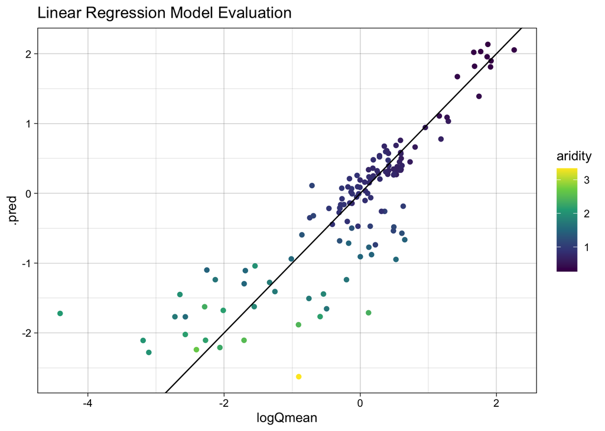

```r
ggplot(lm_data, aes(x = logQmean, y = .pred, colour = aridity)) +
  scale_color_viridis_c() +
  geom_point() +
  geom_abline() +
  labs(title='Linear Regression Model Evaluation')+
  theme_linedraw()
```

```r
metrics(rf_data, truth = logQmean, estimate = .pred)
```

```
# A tibble: 3 × 3
  .metric .estimator .estimate
  <chr>   <chr>          <dbl>
1 rmse    standard       0.587
2 rsq     standard       0.741
3 mae     standard       0.363
```

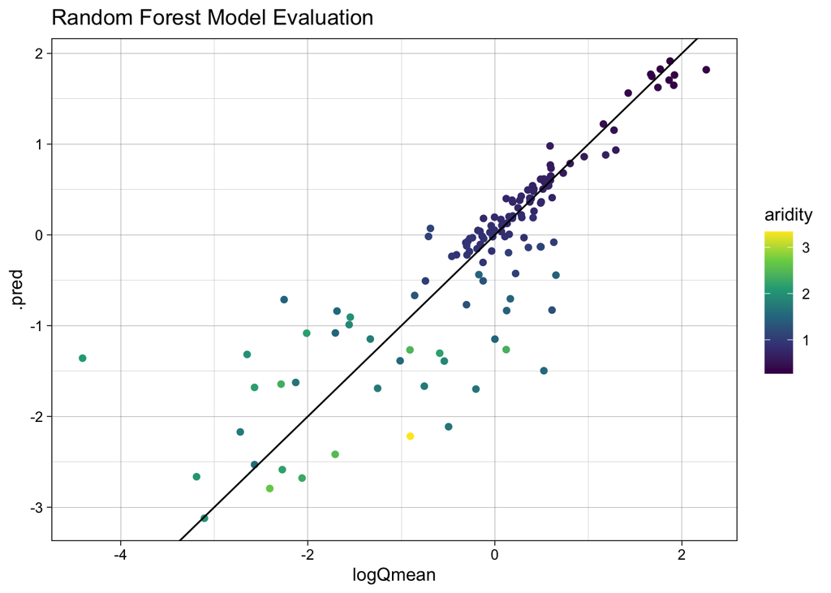

```r
ggplot(rf_data, aes(x = logQmean, y = .pred, colour = aridity)) +
  scale_color_viridis_c() +
  geom_point() +
  geom_abline() +
  labs(title='Random Forest Model Evaluation')+
  theme_linedraw()
```

```r
metrics(bm_data, truth = logQmean, estimate = .pred)
```

```
# A tibble: 3 × 3
  .metric .estimator .estimate
  <chr>   <chr>          <dbl>
1 rmse    standard       0.631
2 rsq     standard       0.702
3 mae     standard       0.397
```

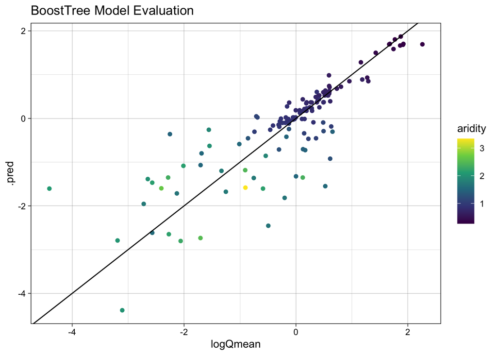

```r
ggplot(bm_data, aes(x = logQmean, y = .pred, colour = aridity)) +
  scale_color_viridis_c() +
  geom_point() +
  geom_abline() +
  labs(title='BoostTree Model Evaluation')+
  theme_linedraw()
```

### Workflow Approach

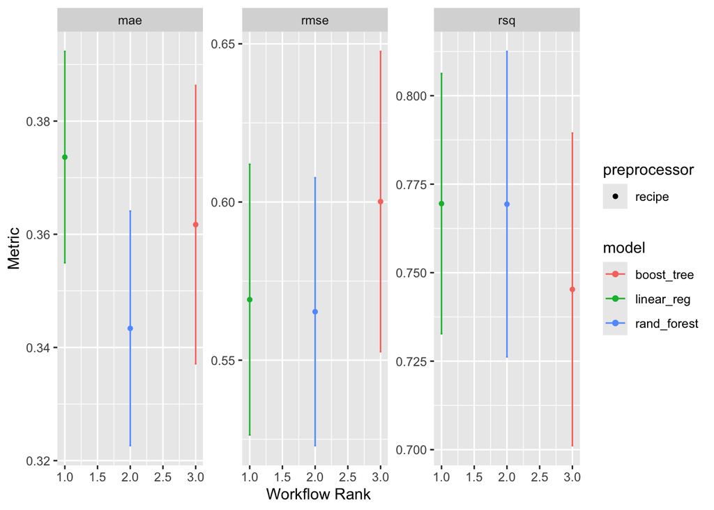

```r
wf <- workflow_set(list(rec), list(Linear=lm_model, Ranger=rf_model, Boost=b_model)) %>%
  workflow_map('fit_resamples', resamples = camels_cv)%>%
  workflow_map(resamples=camels_cv,
               metrics=metric_set(rsq, rmse, mae))
autoplot(wf)
```

```r
rank_results(wf, rank_metric = "rsq", select_best = TRUE)
```

```
# A tibble: 9 × 9
  wflow_id      .config     .metric  mean std_err     n preprocessor model  rank
  <chr>         <chr>       <chr>   <dbl>   <dbl> <int> <chr>        <chr> <int>
1 recipe_Linear Preprocess… mae     0.374  0.0114    10 recipe       line…     1
2 recipe_Linear Preprocess… rmse    0.569  0.0260    10 recipe       line…     1
3 recipe_Linear Preprocess… rsq     0.770  0.0223    10 recipe       line…     1
4 recipe_Ranger Preprocess… mae     0.343  0.0126    10 recipe       rand…     2
5 recipe_Ranger Preprocess… rmse    0.565  0.0257    10 recipe       rand…     2
6 recipe_Ranger Preprocess… rsq     0.769  0.0262    10 recipe       rand…     2
7 recipe_Boost  Preprocess… mae     0.362  0.0150    10 recipe       boos…     3
8 recipe_Boost  Preprocess… rmse    0.600  0.0289    10 recipe       boos…     3
9 recipe_Boost  Preprocess… rsq     0.745  0.0268    10 recipe       boos…     3
```

Based on the testing of the random forest, boost tree, and linear regression models, the random forest model is the best choice. It has a low mean absolute error and rmse which mean there are low levels of errors detected.

The model I selected is the Random forest model with a ranger engine and a regression mode. It works well because it is designed to take multiple predictors and return a prediction based on hyperparameters within the data.

### Building the Specified Model

```r
# Define the model with tuneable parameters
rf_model <- rand_forest(min_n = tune(), trees = tune()) %>%
  set_engine("ranger", importance = "impurity") %>%
  set_mode("regression")

# 2. Create the workflow
rf_wf_tuned <- workflow() %>%
  add_recipe(rec) %>%
  add_model(rf_model)
```

### Check the Tuneable Values

```r
dials<-extract_parameter_set_dials(rf_wf_tuned)

dials$object
```

```
# Trees (quantitative)
```

```
Range: [1, 2000]
```

```
Minimal Node Size (quantitative)
```

```
Range: [2, 40]
```

### Defining the Search Space

```r
my.grid<-dials%>%
  grid_latin_hypercube(size = 20)
```